# Machine Learning Engineer Nanodegree

## Model Evaluation & Validation

## Project: Predicting Boston Housing Prices

Welcome to the first project of the Machine Learning Engineer Nanodegree! In this notebook, some template code has already been provided for you, and you will need to implement additional functionality to successfully complete this project. You will not need to modify the included code beyond what is requested. Sections that begin with **'Implementation'** in the header indicate that the following block of code will require additional functionality which you must provide. Instructions will be provided for each section and the specifics of the implementation are marked in the code block with a 'TODO' statement. Please be sure to read the instructions carefully!

In addition to implementing code, there will be questions that you must answer which relate to the project and your implementation. Each section where you will answer a question is preceded by a **'Question X'** header. Carefully read each question and provide thorough answers in the following text boxes that begin with **'Answer:'**. Your project submission will be evaluated based on your answers to each of the questions and the implementation you provide.

> **Note:** Code and Markdown cells can be executed using the **Shift + Enter** keyboard shortcut. In addition, Markdown cells can be edited by typically double-clicking the cell to enter edit mode.

## Getting Started

In this project, you will evaluate the performance and predictive power of a model that has been trained and tested on data collected from homes in suburbs of Boston, Massachusetts. A model trained on this data that is seen as a *good fit* could then be used to make certain predictions about a home — in particular, its monetary value. This model would prove to be invaluable for someone like a real estate agent who could make use of such information on a daily basis.

The dataset for this project originates from the [UCI Machine Learning Repository](https://archive.ics.uci.edu/ml/datasets/Housing). The Boston housing data was collected in 1978 and each of the 506 entries represent aggregated data about 14 features for homes from various suburbs in Boston, Massachusetts. For the purposes of this project, the following preprocessing steps have been made to the dataset:

- 16 data points have an `'MEDV'` value of 50.0. These data points likely contain **missing or censored values** and have been removed.
- 1 data point has an `'RM'` value of 8.78. This data point can be considered an **outlier** and has been removed.
- The features `'RM'`, `'LSTAT'`, `'PTRATIO'`, and `'MEDV'` are essential. The remaining **non-relevant features** have been excluded.
- The feature `'MEDV'` has been **multiplicatively scaled** to account for 35 years of market inflation.

Run the code cell below to load the Boston housing dataset, along with a few of the necessary Python libraries required for this project. You will know the dataset loaded successfully if the size of the dataset is reported.

```python
# Import libraries necessary for this project
import numpy as np
import pandas as pd
from sklearn.model_selection import ShuffleSplit

# Import supplementary visualizations code visuals.py
import visuals as vs

# Pretty display for notebooks
import matplotlib.pyplot as plt
%matplotlib inline

# Load the Boston housing dataset
data = pd.read_csv('housing.csv')
prices = data['MEDV']
features = data.drop('MEDV', axis = 1)

# Success
print("Boston housing dataset has {} data points with {} variables each.".format(*data.shape))
```

```
Boston housing dataset has 489 data points with 4 variables each.
```

## Data Exploration

In this first section of this project, you will make a cursory investigation about the Boston housing data and provide your observations. Familiarizing yourself with the data through an explorative process is a fundamental practice to help you better understand and justify your results.

Since the main goal of this project is to construct a working model which has the capability of predicting the value of houses, we will need to separate the dataset into **features** and the **target variable**. The **features**, `'RM'`, `'LSTAT'`, and `'PTRATIO'`, give us quantitative information about each data point. The **target variable**, `'MEDV'`, will be the variable we seek to predict. These are stored in `features` and `prices`, respectively.

### Implementation: Calculate Statistics

For your very first coding implementation, you will calculate descriptive statistics about the Boston housing prices. Since `numpy` has already been imported for you, use this library to perform the necessary calculations. These statistics will be extremely important later on to analyze various prediction results from the constructed model.

In the code cell below, you will need to implement the following:

- Calculate the minimum, maximum, mean, median, and standard deviation of `'MEDV'`, which is stored in `prices`.
  - Store each calculation in their respective variable.

**Note:** `prices.std()` returns the sample standard deviation, while `np.std(prices)` returns the population standard deviation by default. Use `np.std(prices, ddof=1)` to calculate the sample standard deviation.

```python
minimum_price = np.min(prices)
maximum_price = np.max(prices)
mean_price = np.mean(prices)
median_price = np.median(prices)
std_price = np.std(prices, ddof=1)

# Show the calculated statistics
print("Statistics for Boston housing dataset:\n")
print("Minimum price: ${}".format(minimum_price))
print("Maximum price: ${}".format(maximum_price))
print("Mean price: ${:.2f}".format(mean_price))
print("Median price ${}".format(median_price))
print("Standard deviation of prices: ${:.2f}".format(std_price))
```

```
Statistics for Boston housing dataset:

Minimum price: $105000.0
Maximum price: $1024800.0
Mean price: $454342.94
Median price $438900.0
Standard deviation of prices: $165340.28
```

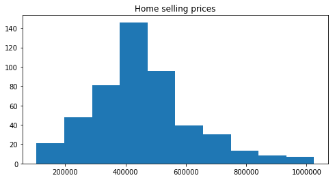

```python
plt.figure(figsize=(8,4))
plt.hist(prices)
plt.title('Home selling prices')
plt.show()
```

### Question 1 - Feature Observation

As a reminder, we are using three features from the Boston housing dataset: `'RM'`, `'LSTAT'`, and `'PTRATIO'`. For each data point (neighborhood):

- `'RM'` is the average number of rooms among homes in the neighborhood.
- `'LSTAT'` is the percentage of homeowners in the neighborhood considered "lower class" (working poor).
- `'PTRATIO'` is the ratio of students to teachers in primary and secondary schools in the neighborhood.

**Using your intuition, for each of the three features above, do you think that an increase in the value of that feature would lead to an** increase **in the value of `'MEDV'` or a** decrease **in the value of `'MEDV'`? Justify your answer for each.**

**Hint:** This problem can phrased using examples like below.

- Would you expect a home that has an `'RM'` value(number of rooms) of 6 be worth more or less than a home that has an `'RM'` value of 7?
- Would you expect a neighborhood that has an `'LSTAT'` value(percent of lower class workers) of 15 have home prices be worth more or less than a neighborhood that has an `'LSTAT'` value of 20?
- Would you expect a neighborhood that has an `'PTRATIO'` value(ratio of students to teachers) of 10 have home prices be worth more or less than a neighborhood that has an `'PTRATIO'` value of 15?

**Answer:**

- An increase in the value of `'RM'` would lead to an increase in the value of `'MEDV'` because houses with more rooms are usually more expensive.
- An increase in the value of `'LSTAT'` would lead to a decrease in the value of `'MEDV'`. Lower class workers can only afford to buy less expensive houses. Thus, the more lower class workers are in a neighborhood, the more lower value homes are in that neighborhood.
- An increase in the value of `'PTRATIO'` would lead to a decrease in the value of `'MEDV'`. If the ratio of students to teachers is high, then the schools in that neighborhood are probably full. This represents a disadvantage for prospective owners because they might be forced to take their children to a school farther away from home, in another neighborhood. Thus, homes in neighborhoods with crowded schools are worth less.

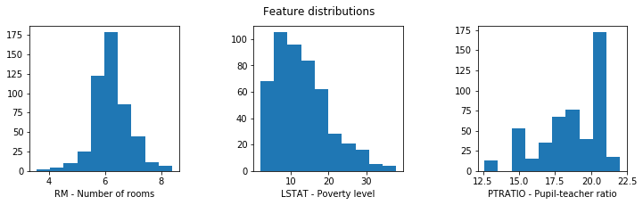

```python
fig, axs = plt.subplots(1, 3, figsize=(12, 3))
fig.suptitle('Feature distributions')

axs[0].hist(features['RM'])
axs[0].set_xlabel('RM - Number of rooms')

axs[1].hist(features['LSTAT'])
axs[1].set_xlabel('LSTAT - Poverty level')

axs[2].hist(features['PTRATIO'])
axs[2].set_xlabel('PTRATIO - Pupil-teacher ratio')

plt.subplots_adjust(wspace=0.5)
plt.show()
```

[1] "Pearson r correlation assumptions", https://www.statisticssolutions.com/correlation-pearson-kendall-spearman/

```python
print("Pearson r correlation between features and selling price:")
print("- RM vs MEDV: {:.2f}".format(features['RM'].corr(prices)))
print("- LSTAT vs MEDV: {:.2f}".format(features['LSTAT'].corr(prices)))
print("- PTRATIO vs MEDV: {:.2f}".format(features['PTRATIO'].corr(prices)))
```

```
Pearson r correlation between features and selling price:
- RM vs MEDV: 0.70
- LSTAT vs MEDV: -0.76
- PTRATIO vs MEDV: -0.52
```

The Pearson r correlation results confirm my initial answer: there's a positive linear correlation between the number of rooms and the selling price, and a negative linear correlation between the poverty level and pupil-teacher ratio features and the selling price. We can also create scatter plots to better visualize the relationship between each feature and the selling price (see figure below).

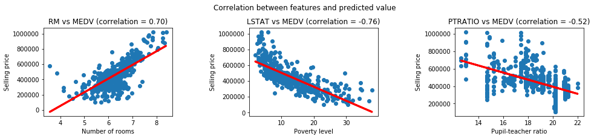

```python
xlabels = {'RM': 'Number of rooms', 'LSTAT': 'Poverty level', 'PTRATIO': 'Pupil-teacher ratio'}

fig, axs = plt.subplots(1, 3, figsize=(16, 3))

for i, col in enumerate(features.columns):
    axs[i].scatter(features[col], prices)

    # Plot regression line
    fit = np.polyfit(features[col], prices, deg=1)
    p = np.poly1d(fit)
    axs[i].plot(features[col], p(features[col]), 'r', lw=3)

    axs[i].set_title('{} vs MEDV (correlation = {:.2f})'.format(col, features[col].corr(prices)))
    axs[i].set_xlabel(xlabels[col])
    axs[i].set_ylabel('Selling price')

plt.subplots_adjust(top=0.8, wspace=0.6)
fig.suptitle('Correlation between features and predicted value')
plt.show()
```

## Developing a Model

In this second section of the project, you will develop the tools and techniques necessary for a model to make a prediction. Being able to make accurate evaluations of each model's performance through the use of these tools and techniques helps to greatly reinforce the confidence in your predictions.

### Implementation: Define a Performance Metric

It is difficult to measure the quality of a given model without quantifying its performance over training and testing. This is typically done using some type of performance metric, whether it is through calculating some type of error, the goodness of fit, or some other useful measurement. For this project, you will be calculating the [*coefficient of determination*](http://stattrek.com/statistics/dictionary.aspx?definition=coefficient_of_determination), R<sup>2</sup>, to quantify your model's performance. The coefficient of determination for a model is a useful statistic in regression analysis, as it often describes how "good" that model is at making predictions.

The values for R<sup>2</sup> range from 0 to 1, which captures the percentage of squared correlation between the predicted and actual values of the **target variable**. A model with an R<sup>2</sup> of 0 is no better than a model that always predicts the *mean* of the target variable, whereas a model with an R<sup>2</sup> of 1 perfectly predicts the target variable. Any value between 0 and 1 indicates what percentage of the target variable, using this model, can be explained by the **features**. *A model can be given a negative R<sup>2</sup> as well, which indicates that the model is **arbitrarily worse** than one that always predicts the mean of the target variable.*

For the `performance_metric` function in the code cell below, you will need to implement the following:

- Use `r2_score` from `sklearn.metrics` to perform a performance calculation between `y_true` and `y_predict`.
- Assign the performance score to the `score` variable.

```python
from sklearn.metrics import r2_score

def performance_metric(y_true, y_predict):
    """ Calculates and returns the performance score between
        true and predicted values based on the metric chosen. """

    score = r2_score(y_true, y_predict)
    return score
```

### Question 2 - Goodness of Fit

Assume that a dataset contains five data points and a model made the following predictions for the target variable:

| True Value | Prediction |
| --- | --- |
| 3.0 | 2.5 |
| -0.5 | 0.0 |
| 2.0 | 2.1 |
| 7.0 | 7.8 |
| 4.2 | 5.3 |

Run the code cell below to use the `performance_metric` function and calculate this model's coefficient of determination.

```python
# Calculate the performance of this model
score = performance_metric([3, -0.5, 2, 7, 4.2], [2.5, 0.0, 2.1, 7.8, 5.3])
print("Model has a coefficient of determination, R^2, of {:.3f}.".format(score))
```

```
Model has a coefficient of determination, R^2, of 0.923.
```

- Would you consider this model to have successfully captured the variation of the target variable?
- Why or why not?

**Hint:** The R2 score is the proportion of the variance in the dependent variable that is predictable from the independent variable. In other words:

- R2 score of 0 means that the dependent variable cannot be predicted from the independent variable.
- R2 score of 1 means the dependent variable can be predicted from the independent variable.
- R2 score between 0 and 1 indicates the extent to which the dependent variable is predictable. An
- R2 score of 0.40 means that 40 percent of the variance in Y is predictable from X.

**Answer:**

The coefficient of determination, $R^2$, can be used to quantify the performance of a regression model, by measuring how well the model explains the variation in the dependent variable.

To calculate it, we first measure the variation in the dependent variable ($SS_{tot}$), as the sum of squared differences between each value and the mean. Then we measure the variation in our model's errors ($SS_{res}$), as the sum of squared differences between the actual and predicted values of the target variable. By dividing the two variations ($\frac{SS_{res}}{SS_{tot}}$), we determine how much of the variation in the dependent variable is not explained by the model.[1] Finally, to obtain the percentage of dependent variable variation explained by the model, we simply need to subtract this value from 1.

$$R^2 = 1 - \frac{SS_{res}}{SS_{tot}}$$

$R^2$ ranges from 0 to 1, with 0 indicating that the model fails to explain the target variable variation, and 1 indicating that it manages to perfectly explain it. If a model is good, then its predictions will be close to the actual values of the target variable and its sum of squared residuals ($SS_{res}$) will be small. This in turn will make $R^2$ have a value closer to 1. On the other hand, if a model is bad, then its sum of squared residuals will be large and it will cause $R^2$ to have a value closer to 0.

Basically, the better a model is able to capture the variation in the target variable, the closer its coefficient of determination will be to 1. In the example above, the model has a coefficient of determination of 0.92, which means it manages to successfully explain 92% of the variation in the target variable.

[1] R-squared or coefficient of determination https://www.khanacademy.org/math/statistics-probability/describing-relationships-quantitative-data/more-on-regression/v/r-squared-or-coefficient-of-determination

### Implementation: Shuffle and Split Data

Your next implementation requires that you take the Boston housing dataset and split the data into training and testing subsets. Typically, the data is also shuffled into a random order when creating the training and testing subsets to remove any bias in the ordering of the dataset.

For the code cell below, you will need to implement the following:

- Use `train_test_split` from `sklearn.model_selection` to shuffle and split the `features` and `prices` data into training and testing sets.
  - Split the data into 80% training and 20% testing.
  - Set the `random_state` for `train_test_split` to a value of your choice. This ensures results are consistent.
- Assign the train and testing splits to `X_train`, `X_test`, `y_train`, and `y_test`.

```python
from sklearn.model_selection import train_test_split

X_train, X_test, y_train, y_test = train_test_split(features, prices, test_size=0.2, random_state=17)

print("Training and testing split was successful.")
```

```
Training and testing split was successful.
```

### Question 3 - Training and Testing

- What is the benefit to splitting a dataset into some ratio of training and testing subsets for a learning algorithm?

**Hint:** Think about how overfitting or underfitting is contingent upon how splits on data is done.

**Answer:**

Splitting the dataset into training and testing subsets allows us to measure how good our model is by testing it on data it hasn't seen before. We can use the training subset to train our model and then test it on the testing subset to see if it generalizes well. If we wouldn't split the dataset and instead trained the model on the entire dataset, then we wouldn't be able to test its performance on unseen data. There would be no way to measure if it generalizes well.

It's important to note that different splits can produce models with very different performances, as seen in the below figure.

```python
from sklearn.tree import DecisionTreeRegressor
from sklearn.model_selection import train_test_split

scores = []
for r in range(1000):
    train_X, test_X, train_y, test_y = train_test_split(features, prices, test_size=0.2, random_state=r)
    reg = DecisionTreeRegressor(random_state=14)
    reg.fit(train_X, train_y)
    pred_y = reg.predict(test_X)
    score = performance_metric(test_y, pred_y)
    scores.append(score)
```

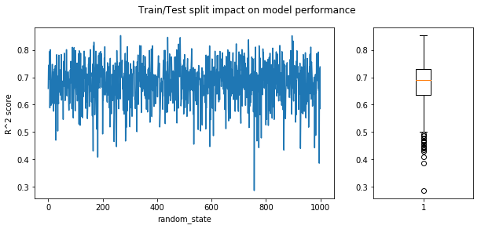

```python
fig, axs = plt.subplots(1, 2, figsize=(10, 4), gridspec_kw={'width_ratios': [3, 1]})
fig.suptitle('Train/Test split impact on model performance')

axs[0].plot(np.arange(1000), scores)
axs[0].set_xlabel('random_state')
axs[0].set_ylabel('R^2 score')

axs[1].boxplot(scores)

plt.show()
```

## Analyzing Model Performance

In this third section of the project, you'll take a look at several models' learning and testing performances on various subsets of training data. Additionally, you'll investigate one particular algorithm with an increasing `'max_depth'` parameter on the full training set to observe how model complexity affects performance. Graphing your model's performance based on varying criteria can be beneficial in the analysis process, such as visualizing behavior that may not have been apparent from the results alone.

### Learning Curves

The following code cell produces four graphs for a decision tree model with different maximum depths. Each graph visualizes the learning curves of the model for both training and testing as the size of the training set is increased. Note that the shaded region of a learning curve denotes the uncertainty of that curve (measured as the standard deviation). The model is scored on both the training and testing sets using R<sup>2</sup>, the coefficient of determination.

Run the code cell below and use these graphs to answer the following question.

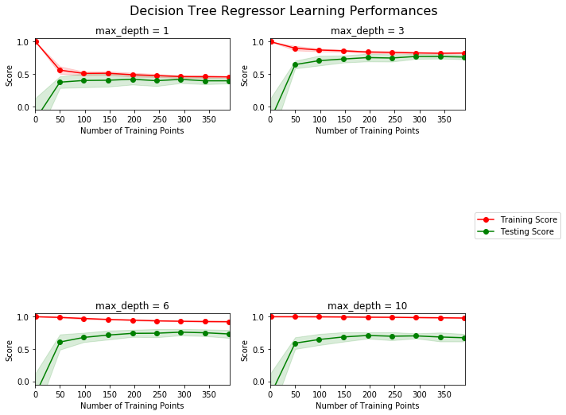

```python
# Produce learning curves for varying training set sizes and maximum depths
vs.ModelLearning(features, prices)
```

### Question 4 - Learning the Data

- Choose one of the graphs above and state the maximum depth for the model.
- What happens to the score of the training curve as more training points are added? What about the testing curve?
- Would having more training points benefit the model?

**Hint:** Are the learning curves converging to particular scores? Generally speaking, the more data you have, the better. But if your training and testing curves are converging with a score above your benchmark threshold, would this be necessary? Think about the pros and cons of adding more training points based on if the training and testing curves are converging.

**Answer:** Model with `max_depth=3`

As we add more training points, the model starts to be less accurate on the training set and its training score slowly decreases. However, it starts to better capture the relationship between the features and the target variable, and its testing score increases. Having more than 400 training points would not produce a noticeable improvement in the model's performance because the learning curves are already converging to a value of 0.8.

In general, if the learning curves are converging to a score above our desired performance, then we've successfully built a good model and it's not necessary to add more training points. Although the testing score will get closer to the training score, it will do so only by small increments and it will eventually stop. Moreover, as we add more training points, the training dataset will become larger and it will take a longer time to train a model on it.

As a side note, we could try improving the model's performance by adding more features. However, we need to make sure the features are relevant. Otherwise, we risk overfitting the data by learning irrelevant information from the data and actually decreasing the model's performance. Ultimately, choosing the features to train a model on comes down to identifying the ones that are the strongest predictors of the target variable.

### Complexity Curves

The following code cell produces a graph for a decision tree model that has been trained and validated on the training data using different maximum depths. The graph produces two complexity curves — one for training and one for validation. Similar to the **learning curves**, the shaded regions of both the complexity curves denote the uncertainty in those curves, and the model is scored on both the training and validation sets using the `performance_metric` function.

**Run the code cell below and use this graph to answer the following two questions Q5 and Q6.**

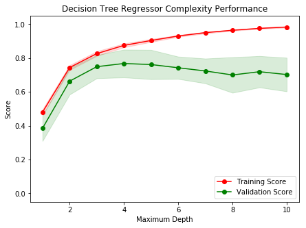

```python
vs.ModelComplexity(X_train, y_train)
```

### Question 5 - Bias-Variance Tradeoff

- When the model is trained with a maximum depth of 1, does the model suffer from high bias or from high variance?
- How about when the model is trained with a maximum depth of 10? What visual cues in the graph justify your conclusions?

**Hint:** High bias is a sign of underfitting(model is not complex enough to pick up the nuances in the data) and high variance is a sign of overfitting(model is by-hearting the data and cannot generalize well). Think about which model(depth 1 or 10) aligns with which part of the tradeoff.

**Answer:**

The model trained with a maximum depth of 1 suffers from high bias because it has a poor performance on both the training and validation sets. It's too simplistic and it fails to capture any meaningful information from the features.

On the other hand, the model trained with a maximum depth of 10 suffers from high variance because it has a great performance on the training set and a much lower performance on the validation set. This model is memorizing the training data and it fails to generalize well.

To overcome these issues, we could try tuning the model's hyper-parameters or increasing the size of the training set. We could also try adding more relevant features to the dataset in the case of a high bias model, or removing irrelevant features in the case of a high variance model. If nothing works, then we should look for another learning algorithm that is better suited for our problem.

### Question 6 - Best-Guess Optimal Model

- Which maximum depth do you think results in a model that best generalizes to unseen data?
- What intuition lead you to this answer?

**Hint:** Look at the graph above Question 5 and see where the validation scores lie for the various depths that have been assigned to the model. Does it get better with increased depth? At what point do we get our best validation score without overcomplicating our model? And remember, Occams Razor states "Among competing hypotheses, the one with the fewest assumptions should be selected."

**Answer:**

The highest validation scores, around 0.7, are obtained by the models trained with maximum depths of 4, 5 and 3 (noted M4, M5 and M3 respectively). Although M4 and M5 have higher validation scores than M3, the differences between their training and validation scores are higher as well. This means they are overfitting and they will do a poor job on unseen data. In contrast, M3 obtains good training and validation scores, without overfitting the data. This makes it the model with the best chance at generalizing well on unseen data.

## Evaluating Model Performance

In this final section of the project, you will construct a model and make a prediction on the client's feature set using an optimized model from `fit_model`.

### Question 7 - Grid Search

- What is the grid search technique?
- How it can be applied to optimize a learning algorithm?

**Hint:** When explaining the Grid Search technique, be sure to touch upon why it is used, what the 'grid' entails and what the end goal of this method is. To solidify your answer, you can also give an example of a parameter in a model that can be optimized using this approach.

**Answer:**

Grid Search is a technique that helps us determine which hyper-parameter values offer the best performance.

*Note that the hyper-parameters of a learning algorithm are distinct from its parameters. The hyper-parameters are properties that we manually set before training a model, while parameters are values that the algorithm must learn from the training data in order to produce a good model. In essence, the hyper-parameters control the final values of the parameters.[1]*

For a given learning algorithm and a list of hyper-parameters with different possible values, Grid Search trains a model for each combination of hyper-parameter values and selects the one with the best performance. It's a useful technique because it saves us from manually trying out all the different combinations.

For example, if we wanted to optimize a Decision Tree model by tuning its `max_depth` and `min_samples_split` hyper-parameters, we could:

1. Create a list of all possible values for each hyper-parameter:
   - `[1, 3, 5]` for the maximum depth and
   - `[10, 50, 100]` for the minimum samples required to split a node
2. Apply Grid Search to find the best `(max_depth, min_samples_split)` pair.

The table below illustrates hypothetical performances we could obtain for each pair. Based on this, we can conclude that the best hyper-parameter values are `max_depth=3` and `min_samples_split=50`.

|  | max_depth=1 | max_depth=3 | max_depth=5 |
| --- | --- | --- | --- |
| **min_samples_split=10** | 0.3 | 0.6 | 0.6 |
| **min_samples_split=50** | 0.4 | **0.8** | 0.6 |
| **min_samples_split=100** | 0.3 | 0.7 | 0.5 |

[1] "Parameters vs Hyperparameters" https://www.coursera.org/lecture/neural-networks-deep-learning/parameters-vs-hyperparameters-TBvb5

### Question 8 - Cross-Validation

- What is the k-fold cross-validation training technique?
- What benefit does this technique provide for grid search when optimizing a model?

**Hint:** When explaining the k-fold cross validation technique, be sure to touch upon what 'k' is, how the dataset is split into different parts for training and testing and the number of times it is run based on the 'k' value.

When thinking about how k-fold cross validation helps grid search, think about the main drawbacks of grid search which are hinged upon **using a particular subset of data for training or testing** and how k-fold cv could help alleviate that. You can refer to the [docs](http://scikit-learn.org/stable/modules/cross_validation.html#cross-validation) for your answer.

**Answer:**

K-fold cross-validation allows us to measure how well our model generalizes on unseen data, without compromising the testing dataset. Moreover, it avoids reducing the training dataset size, which happens when we hold out a part of the training set as a validation set. It does this by partitioning the training dataset into *k* subsets, training a model on *k-1* subsets and then testing the model on the remaining partition. It repeats this process *k* times such that each time it uses a different partition for testing the model. The final performance is calculated as the average of all performances obtained through the *k* iterations.

For example, a 3-fold cross-validation would split the training set into 3 partitions, P1, P2 and P3, and do the following:

1. Train a model on P2 and P3 and test it on P1, obtaining a performance *p1*
2. Train a model on P1 and P3 and test it on P2, obtaining a performance *p2*
3. Train a model on P1 and P2 and test it on P3, obtaining a performance *p3*
4. Calculate the final performance as the average of *p1*, *p2* and *p3*

Grid search has a major disadvantage when using a single subset for training or testing, in that it's prone to overfitting and it could mislead us into choosing a model that won't generalize well. We can overcome this by combining grid search with cross-validation. Cross-validation will prevent grid search from overfitting by training and testing the models repeatedly on different parts of the dataset.

### Implementation: Fitting a Model

Your final implementation requires that you bring everything together and train a model using the **decision tree algorithm**. To ensure that you are producing an optimized model, you will train the model using the grid search technique to optimize the `'max_depth'` parameter for the decision tree. The `'max_depth'` parameter can be thought of as how many questions the decision tree algorithm is allowed to ask about the data before making a prediction. Decision trees are part of a class of algorithms called *supervised learning algorithms*.

In addition, you will find your implementation is using `ShuffleSplit()` for an alternative form of cross-validation (see the `'cv_sets'` variable). While it is not the K-Fold cross-validation technique you describe in **Question 8**, this type of cross-validation technique is just as useful!. The `ShuffleSplit()` implementation below will create 10 (`'n_splits'`) shuffled sets, and for each shuffle, 20% (`'test_size'`) of the data will be used as the *validation set*. While you're working on your implementation, think about the contrasts and similarities it has to the K-fold cross-validation technique.

For the `fit_model` function in the code cell below, you will need to implement the following:

- Use [`DecisionTreeRegressor`](http://scikit-learn.org/stable/modules/generated/sklearn.tree.DecisionTreeRegressor.html) from `sklearn.tree` to create a decision tree regressor object.
  - Assign this object to the `'regressor'` variable.
- Create a dictionary for `'max_depth'` with the values from 1 to 10, and assign this to the `'params'` variable.
- Use [`make_scorer`](http://scikit-learn.org/stable/modules/generated/sklearn.metrics.make_scorer.html) from `sklearn.metrics` to create a scoring function object.
  - Pass the `performance_metric` function as a parameter to the object.
  - Assign this scoring function to the `'scoring_fnc'` variable.
- Use [`GridSearchCV`](http://scikit-learn.org/0.20/modules/generated/sklearn.model_selection.GridSearchCV.html) from `sklearn.model_selection` to create a grid search object.
  - Pass the variables `'regressor'`, `'params'`, `'scoring_fnc'`, and `'cv_sets'` as parameters to the object.
  - Assign the `GridSearchCV` object to the `'grid'` variable.

```python
from sklearn.metrics import make_scorer
from sklearn.tree import DecisionTreeRegressor
from sklearn.model_selection import GridSearchCV

def fit_model(X, y):
    """ Performs grid search over the 'max_depth' parameter for a
        decision tree regressor trained on the input data [X, y].
        Evaluates model performance using R^2 score. """

    # Create cross-validation sets from the training data
    cv_sets = ShuffleSplit(n_splits = 10, test_size = 0.20, random_state = 0)

    regressor = DecisionTreeRegressor(random_state=14)

    params = {'max_depth': list(range(1, 11))}

    # Transform 'performance_metric' into a scoring function
    scoring_fnc = make_scorer(performance_metric)

    grid = GridSearchCV(regressor, params, scoring=scoring_fnc, cv=cv_sets)

    # Fit the grid search object to the data to compute the optimal model
    grid = grid.fit(X, y)

    # Return the optimal model after fitting the data and its score
    return grid.best_estimator_, grid.best_score_
```

### Making Predictions

Once a model has been trained on a given set of data, it can now be used to make predictions on new sets of input data. In the case of a *decision tree regressor*, the model has learned *what the best questions to ask about the input data are*, and can respond with a prediction for the **target variable**. You can use these predictions to gain information about data where the value of the target variable is unknown — such as data the model was not trained on.

### Question 9 - Optimal Model

- What maximum depth does the optimal model have? How does this result compare to your guess in **Question 6**?

Run the code block below to fit the decision tree regressor to the training data and produce an optimal model.

```python
# Fit the training data to the model using grid search
reg, score = fit_model(X_train, y_train)

# Produce the value for 'max_depth'
print("Parameter 'max_depth' is {} for the optimal model.".format(reg.get_params()['max_depth']))
print('Optimal model has an R^2 score of {:.4f}'.format(score))
```

```
Parameter 'max_depth' is 4 for the optimal model.
Optimal model has an R^2 score of 0.7681
```

**Hint:** The answer comes from the output of the code snipped above.

**Answer:** The optimal model has a maximum depth of 4 (M4).

My guess was that the model with a maximum depth of 3 (M3) was the best because it had a similar validation score to M4 and its variance was lower. However, it turns out that M4's variance wasn't high enough to cause it to overfit.

### Question 10 - Predicting Selling Prices

Imagine that you were a real estate agent in the Boston area looking to use this model to help price homes owned by your clients that they wish to sell. You have collected the following information from three of your clients:

| Feature | Client 1 | Client 2 | Client 3 |
| --- | --- | --- | --- |
| Total number of rooms in home | 5 rooms | 4 rooms | 8 rooms |
| Neighborhood poverty level (as %) | 17% | 32% | 3% |
| Student-teacher ratio of nearby schools | 15-to-1 | 22-to-1 | 12-to-1 |

- What price would you recommend each client sell his/her home at?
- Do these prices seem reasonable given the values for the respective features?

**Hint:** Use the statistics you calculated in the **Data Exploration** section to help justify your response. Of the three clients, client 3 has has the biggest house, in the best public school neighborhood with the lowest poverty level; while client 2 has the smallest house, in a neighborhood with a relatively high poverty rate and not the best public schools.

Run the code block below to have your optimized model make predictions for each client's home.

```python
# Produce a matrix for client data
client_data = [[5, 17, 15], # Client 1
               [4, 32, 22], # Client 2
               [8, 3, 12]]  # Client 3

# Show predictions
for i, price in enumerate(reg.predict(client_data)):
    print("Predicted selling price for Client {}'s home: ${:,.2f}".format(i+1, price))
```

```
Predicted selling price for Client 1's home: $412,950.00
Predicted selling price for Client 2's home: $234,529.79
Predicted selling price for Client 3's home: $896,962.50
```

**Answer:**

The model predicted the following selling prices:

- **\$412,950.00** for Client 1's house
- **\$234,529.79** for Client 2's house
- **\$896,962.50** for Client 3's house

The prediction for Client 3's house seems good because it's a big house in a good neighborhood and the model successfully predicted a value closer to the maximum selling price observed in the dataset (\$1,024,800.0). At the opposite end, Client 2 has a much smaller house located in a poorer neighborhood. In this case the model manages to price it accordingly, towards the minimum selling price observed in the dataset (\$105,000.0). Lastly, Client 1's house sits somewhere in between the other two houses, as it's better than Client 2's house, but not as great as Client 3's house. Thus, this house's predicted selling price seems good in comparison with the other two predictions.

In conclusion, the selling prices predicted by the model seem reasonable with respect to each house's features. The figure below shows where each client's house stands compared to all other houses on the market.

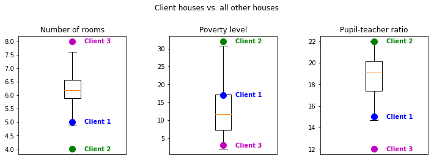

```python
feature_names = {'RM': 'Number of rooms', 'LSTAT': 'Poverty level', 'PTRATIO': 'Pupil-teacher ratio'}
colors=['b', 'g', 'm']

fig, axs = plt.subplots(1, 3, figsize=(12, 4))
fig.suptitle('Client houses vs. all other houses')

for i, col in enumerate(features.columns):
    axs[i].boxplot(features[col], showfliers=False)
    axs[i].set_title(feature_names[col])

    # Plot each client's house features
    for j in range(3):
        axs[i].plot(1, client_data[j][i], 'o', markersize=10, color=colors[j])
        axs[i].annotate('Client ' + str(j+1), xy=(1, client_data[j][i]),
                        xytext=(20, -3), textcoords='offset points',
                        fontweight='bold', color=colors[j])
        axs[i].xaxis.set_visible(False)

plt.subplots_adjust(top=0.8, wspace=0.4)
plt.show()
```

**Extra questions:**

- What kind of relationship do the independent variables have with the dependent variable?

As seen in the figure "Correlation between features and predicted value" from Answer 1, there is a linear relationship between each independent variable and the target variable. For example, we can see that an increase in the number of rooms leads to a proportional increase in the house's selling price.

- Decision Tree, and in general tree based models, handle a kind of relationship between the IVs and DV better than non-tree based models. Which kind of relationship is that? How do tree based models handle that kind of relationship?

Tree based models handle non-linear relationships better because they partition the feature space in a set of rectangles and attribute a particular value to each one.[1] This is in contrast to other types of models, which attempt to express the relationship between the independent variables and the dependent variable as an equation.

[1] "The Elements of Statistical Learning", 2nd Ed., Trevor Hastie. Robert Tibshirani. Jerome Friedman

### Sensitivity

An optimal model is not necessarily a robust model. Sometimes, a model is either too complex or too simple to sufficiently generalize to new data. Sometimes, a model could use a learning algorithm that is not appropriate for the structure of the data given. Other times, the data itself could be too noisy or contain too few samples to allow a model to adequately capture the target variable — i.e., the model is underfitted.

**Run the code cell below to run the `fit_model` function ten times with different training and testing sets to see how the prediction for a specific client changes with respect to the data it's trained on.**

```python
vs.PredictTrials(features, prices, fit_model, client_data)
```

```
Trial 1: $391,183.33
Trial 2: $419,700.00
Trial 3: $415,800.00
Trial 4: $420,622.22
Trial 5: $418,377.27
Trial 6: $411,931.58
Trial 7: $399,663.16
Trial 8: $407,232.00
Trial 9: $351,577.61
Trial 10: $413,700.00

Range in prices: $69,044.61
```

### Question 11 - Applicability

- In a few sentences, discuss whether the constructed model should or should not be used in a real-world setting.

**Hint:** Take a look at the range in prices as calculated in the code snippet above. Some questions to answering:

- How relevant today is data that was collected from 1978? How important is inflation?
- Are the features present in the data sufficient to describe a home? Do you think factors like quality of apppliances in the home, square feet of the plot area, presence of pool or not etc should factor in?
- Is the model robust enough to make consistent predictions?
- Would data collected in an urban city like Boston be applicable in a rural city?
- Is it fair to judge the price of an individual home based on the characteristics of the entire neighborhood?

**Answer:**

Based on the trials performed above, we can see that the model predicts very different selling prices for the same house, ranging from \$351,577.61 to \$420,622.22. This inconsistency is far from ideal and it's probably caused by the small size of the dataset. Regardless of the cause, this behavior indicates that our model is not robust enough.

Before deciding whether this model is appropriate for real-world usage, it should be noted that the data we trained it on was collected in 1978 and it's unlikely to be relevant today. Even though the selling prices in this dataset have been scaled to take into account the market inflation, the new prices are not representative for today's landscape. In addition, houses in some neighborhoods might have significantly appreciated or depreciated in value since 1978 for reasons other than inflation, such as an increased demand in that region.

Another thing to note is that this model is only applicable to Boston, as house prices vary greatly between different cities and between urban and rural cities alike. It's difficult to compare houses in different cities because each city is unique in the services it provides to its residents and in its job market.

Also, the three features that we've used in training the model – average number of rooms, neighborhood poverty level and pupil-teacher ratio of nearby schools – are not sufficient to describe a house. They only allow us to predict a house's selling price based on the number of rooms it has and the neighborhood it's located in. In other words, the model tries to answer the question "How much would it cost to buy a house with N rooms in neighborhood B?".

We could improve it by adding more relevant features to better describe the houses, such as: total surface area, number of floors, the year it was built, presence of a pool or of a garage and the quality of its appliances. At the same time, we should keep using the neighborhood-related features because the kind of neighborhood a house is located in has a huge impact on its value. It's important to take the neighborhood into account when estimating a home's selling price. In my opinion, it's fair to judge a home by its neighborhood, as long as that's not the only aspect we're using in our judgement.

Taking everything into account, our current model could be used by a real estate agent only to determine a starting point for pricing a client's house in the Boston area. After that, he should carefully analyze the specific features of the client's house and adjust the model's predicted value accordingly.

> **Note**: Once you have completed all of the code implementations and successfully answered each question above, you may finalize your work by exporting the iPython Notebook as an HTML document. You can do this by using the menu above and navigating to  
> **File -> Download as -> HTML (.html)**. Include the finished document along with this notebook as your submission.